## # Assignment 3

author: “Ana Zhibaj” date: “who even knows anymore honestly” output: html_document —

```r
library(sf)
library(tidyverse)
library(ggthemes)
library(ggspatial)
library(units)
library(nngeo)
library(wesanderson)
library(extrafont)
library(extrafontdb)
library(units)
```

I pulled climate vulnerability (a group of variables that measure how vulnerable a tract is to climate crisis), open spaces, trees, and hubway stations from analyze Boston website.

```r
hubwaystations <- st_read("http://bostonopendata-boston.opendata.arcgis.com/datasets/ee7474e2a0aa45cbbdfe0b747a5eb032_0.kml?outSR=%7B%22latestWkid%22%3A3857%2C%22wkid%22%3A102100%7D",
                  quiet = TRUE)
trees <- st_read("http://bostonopendata-boston.opendata.arcgis.com/datasets/ce863d38db284efe83555caf8a832e2a_1.kml",
                 quiet = TRUE)
open_space <- st_read("http://bostonopendata-boston.opendata.arcgis.com/datasets/2868d370c55d4d458d4ae2224ef8cddd_7.kml",
                 quiet = TRUE)
climate_vulnerability <- st_read("200929_climatevulnerability.shp",
                   quiet = TRUE)
water <- st_read("http://bostonopendata-boston.opendata.arcgis.com/datasets/2b3c0fa13b1c468eb702a3645fcc6bcb_5.kml",
                 quiet = TRUE)
```

## Transforming the data

I transformed the maps using the projection system.

```r
MA_state_plane <- "+proj=lcc +lat_1=41.71666666666667 +lat_2=42.68333333333333 +lat_0=41 +lon_0=-71.5 +x_0=200000 +y_0=750000 +ellps=GRS80 +units=m +no_defs"
hubwaystations <- hubwaystations %>%
  st_transform(MA_state_plane)
trees <- trees %>%
  st_transform(MA_state_plane)
open_space <- open_space %>%
  st_transform(MA_state_plane)
water <- water %>%
  st_transform(MA_state_plane)
climate_vulnerability <- climate_vulnerability %>%
  st_transform(MA_state_plane)
```

I’ll draw a quick map now to see how the data look.

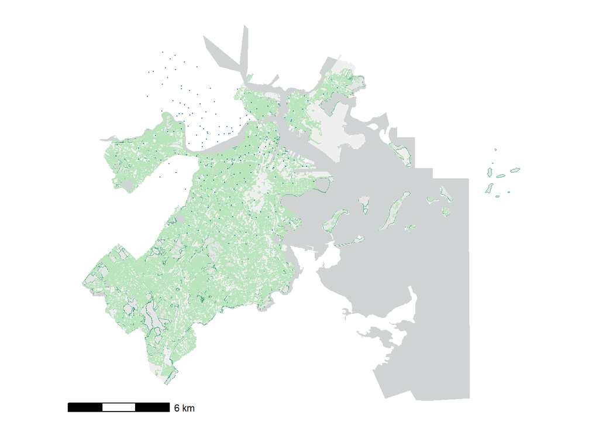

```r
ggplot(water) +
  geom_sf(data= climate_vulnerability, fill = "#f0efef", color = NA) +
  geom_sf(data = open_space, color = "#41ae76", size = 0.01) +
  geom_sf(fill = "#d0d3d4", color = NA) +
  geom_sf(data = trees, color = "#bae4bc", size = 0.005) +
  geom_sf(data = hubwaystations, color = "#0868ac", size = 0.01) +
  theme_map() +
  annotation_scale()
```

## Creating a buffer

I’ll create a 300-m radius buffer around hubway stations.

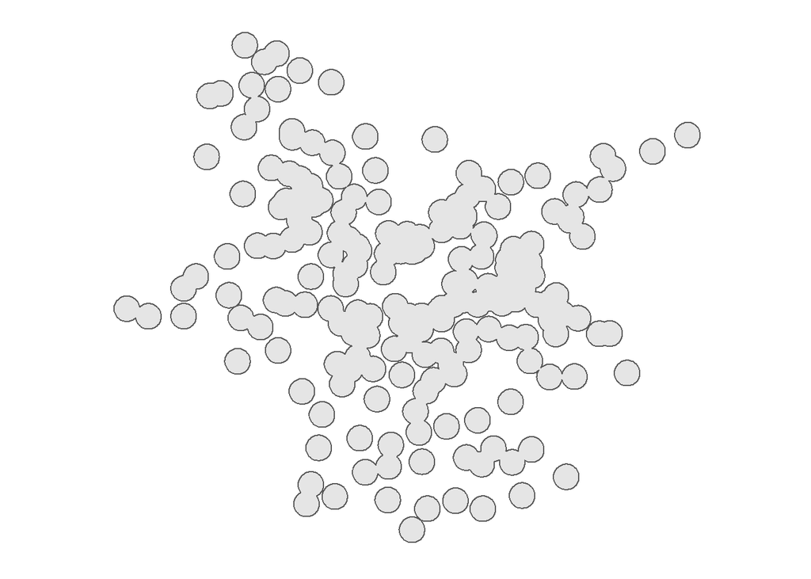

```r
hubwaystations_bf <- st_buffer(hubwaystations, dist = 300) %>%
  st_union()
ggplot(hubwaystations_bf) +
  geom_sf() +
  theme_map()
```

## Subsetting points with a polygon

How many trees are there on a 300-m radius from the hubway stations?

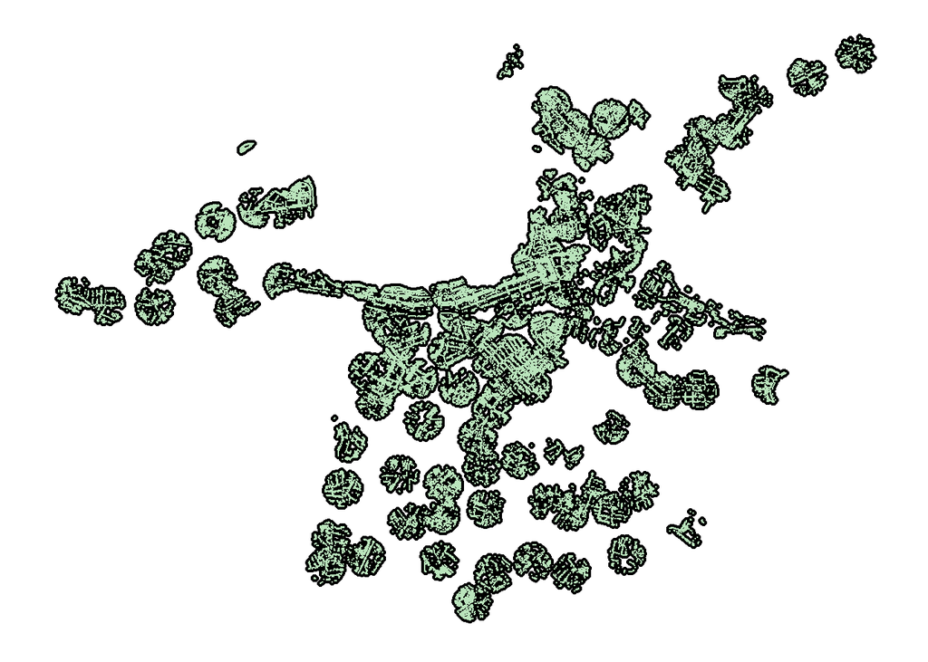

```r
hubwaystations_trees <- trees[hubwaystations_bf,]

ggplot(hubwaystations_trees) +
  geom_sf() +
  geom_sf(data = hubwaystations_trees,
          color = "#bae4bc",
          size = 0.01) +
  theme_map()
```

```r
trees <- trees %>%
  st_join(hubwaystations_trees) %>%
  mutate(by_hubwaystations = !is.na(Name.y))
```

Now we can calculate how many trees are within 300 meters of a hubway station:

```r
n_hubwaystations_trees <- sum(trees$by_hubwaystations)
n_hubwaystations_trees
```

```
## [1] 59110
```

And what percent of all trees does this represent?

```r
n_trees <- length(trees$by_hubwaystations)
pct_hubwst_trees <-n_hubwaystations_trees / n_trees
pct_hubwst_trees
```

```
## [1] 0.2928369
```

About 29 percent of all trees in Boston are within 300 meters of a hubway station. I’ll include a note about the number and percent of trees near hubway stations.

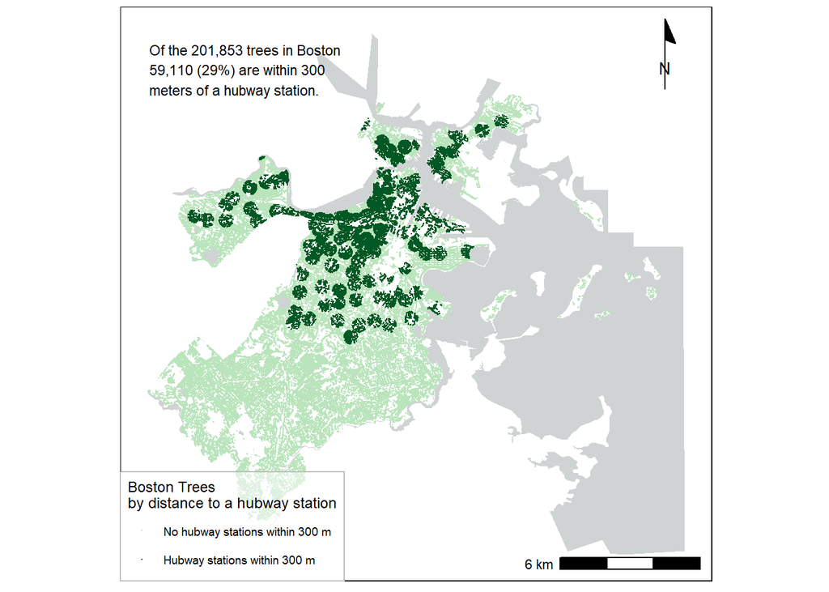

```r
left_side  <- st_bbox(trees)$xmin
top_side <- st_bbox(trees)$ymax
ggplot(water) +
  geom_sf(fill = "#d0d3d4", color = NA) +
  geom_sf(data = trees, size = 0.01,
          aes(color = by_hubwaystations)) +
  scale_color_manual(values = c("#bae4bc", "#005824"),
          name = "Boston Trees\nby distance to a hubway station",
          labels = c("No hubway stations within 300 m",
                     "Hubway stations within 300 m")) +
  annotation_scale(location = "br") +
  annotation_north_arrow(location = "tr",
                         style = north_arrow_minimal()) +
  annotate(geom = "text", x = left_side,
           y = top_side,
           label = paste("Of the ",
                         prettyNum(n_trees, big.mark = ","),
                         " trees in Boston\n",
                         prettyNum(n_hubwaystations_trees, big.mark = ","),
                         " (",
                         prettyNum(100*pct_hubwst_trees, digits = 0),
                         "%) are within 300\nmeters of a hubway station.",
                         sep = ""),
           hjust = 0, vjust = 0, size = 3) +
  theme_map() +
  theme(panel.background = element_rect(fill = "white"),
        legend.background = element_rect(fill = alpha("white", 0.5),
                                         color = "gray"))
```

## Counting points in a polygon

What if I wanted to know how many trees are in Boston neighborhoods that are particularly vulnerable to the climate crisis? First, I’ll filter the climate vulnerability variables to show the tracts the most affected and see how they compare to green and open space access.

```r
max_climate_vulnerability <- climate_vulnerability %>%
  filter(Low_to_No > 1000) %>%
  select(FID_1, GEOID10, Low_to_No) # I selected the tracts with more than 1000 people that have reported low to no income. I'll compare how this relates to the access they have to open space and trees.
```

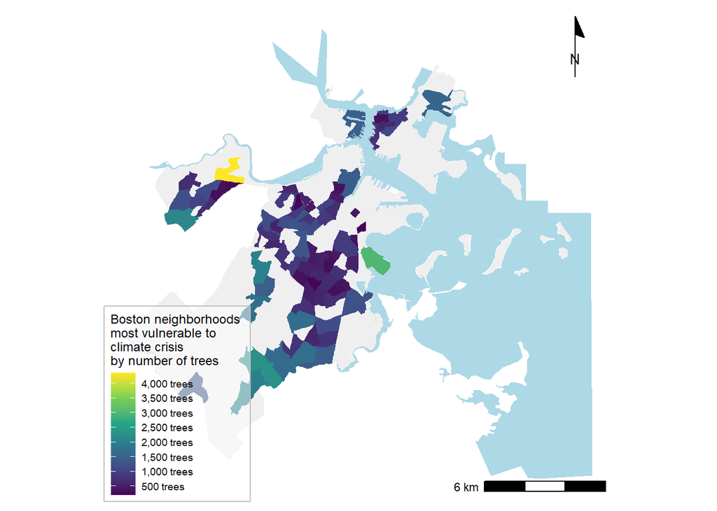

```r
max_climate_vulnerability <- max_climate_vulnerability %>%
  mutate(num_trees = lengths(st_covers(max_climate_vulnerability, trees)))
ggplot(max_climate_vulnerability) +
  geom_sf(data = water, fill = "lightblue", color = NA) +
  geom_sf(data= climate_vulnerability, fill = "#f0efef", color = NA) +
  geom_sf(color = NA,
          aes(fill = num_trees)) +
  scale_fill_viridis_c(name = "Boston neighborhoods \nmost vulnerable to \nclimate crisis \nby number of trees",
                       breaks = breaks <- seq(0, 6000, by = 500),
                       labels = paste(prettyNum(breaks, big.mark = ","),
                                      "trees")) +
  annotation_scale(location = "br") +
  annotation_north_arrow(location = "tr",
                         style = north_arrow_minimal()) +
theme_map() +
  theme(legend.background = element_rect(fill = alpha("white", 0.5),
                                         color = "gray"))
```

## Calculating areas and densities

Density of trees in climate-vulnerable neighborhoods.

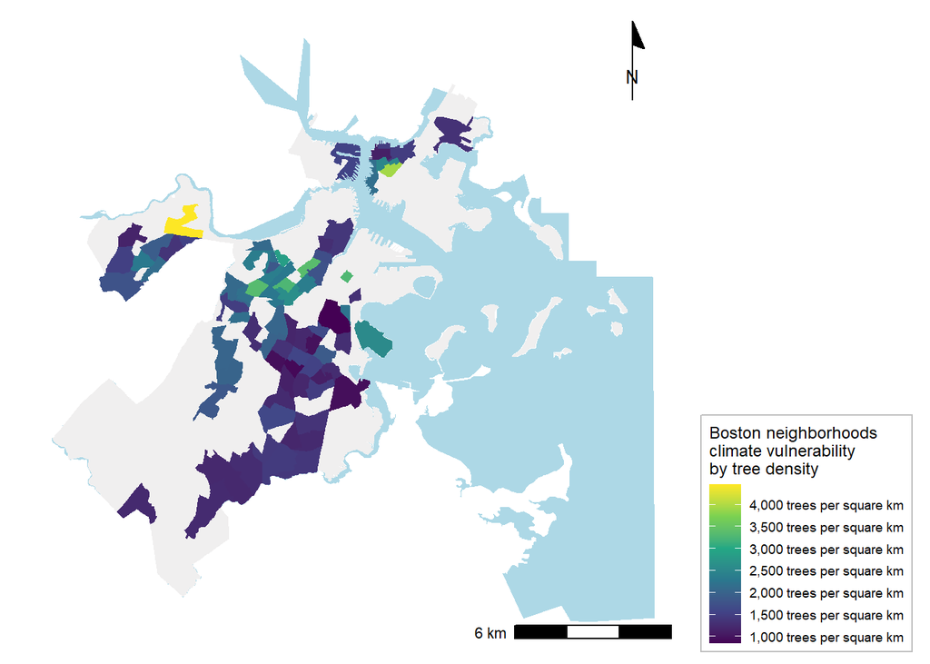

```r
max_climate_vulnerability <- max_climate_vulnerability %>%
  mutate(area = set_units(st_area(max_climate_vulnerability), km^2)) %>%
  mutate(tree_dens = as.numeric(num_trees / area))
ggplot(max_climate_vulnerability) +
  geom_sf(data = water, fill = "lightblue", color = NA) +
  geom_sf(data= climate_vulnerability, fill = "#f0efef", color = NA) +
  geom_sf(color = NA,
          aes(fill = tree_dens)) +
    scale_fill_viridis_c(name =
                           "Boston neighborhoods\nclimate vulnerability\nby tree density",
                       breaks = breaks <- seq(0, 6000, by = 500),
                       labels = paste(prettyNum(breaks, big.mark = ","),
                                      "trees per square km")) +
  annotation_scale(location = "br") +
  annotation_north_arrow(location = "tr",
                         style = north_arrow_minimal()) +
theme_map() +
  theme(legend.position = "right",
    legend.background = element_rect(fill = alpha("white", 0.5),
                                         color = "gray"))
```

I’m plotting a map counting trees in open spaces.

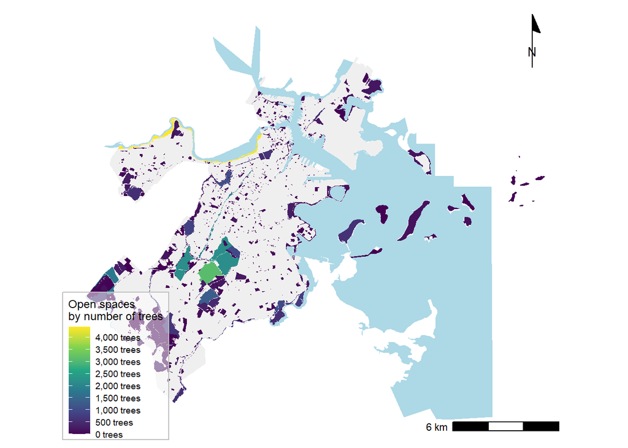

```r
open_space <- open_space %>%
  mutate(num_treesos = lengths(st_covers(open_space, trees)))
ggplot(open_space) +
  geom_sf(data = water, fill = "lightblue", color = NA) +
  geom_sf(data= climate_vulnerability, fill = "#f0efef", color = NA) +
  geom_sf(color = NA,
          aes(fill = num_treesos)) +
  scale_fill_viridis_c(name = "Open spaces \nby number of trees",
                       breaks = breaks <- seq(0, 4000, by = 500),
                       labels = paste(prettyNum(breaks, big.mark = ","),
                                      "trees")) +
  annotation_scale(location = "br") +
  annotation_north_arrow(location = "tr",
                         style = north_arrow_minimal()) +
theme_map() +
  theme(legend.background = element_rect(fill = alpha("white", 0.5),
                                         color = "gray"))
```

## Finding the closest point

The average distance of a tree from the hubway station.

```r
hubwaystations <- hubwaystations %>%
  mutate(tree_dist = st_nn(hubwaystations, trees,
                           returnDist = TRUE)$dist) %>%
  mutate(tree_dist = as.numeric(tree_dist))
```

Now I can calculate the average distance from a hubway station to the nearest tree.

```r
avg_tree_dist <- mean(hubwaystations$tree_dist)
avg_tree_dist
```

```
## [1] 402.7765
```

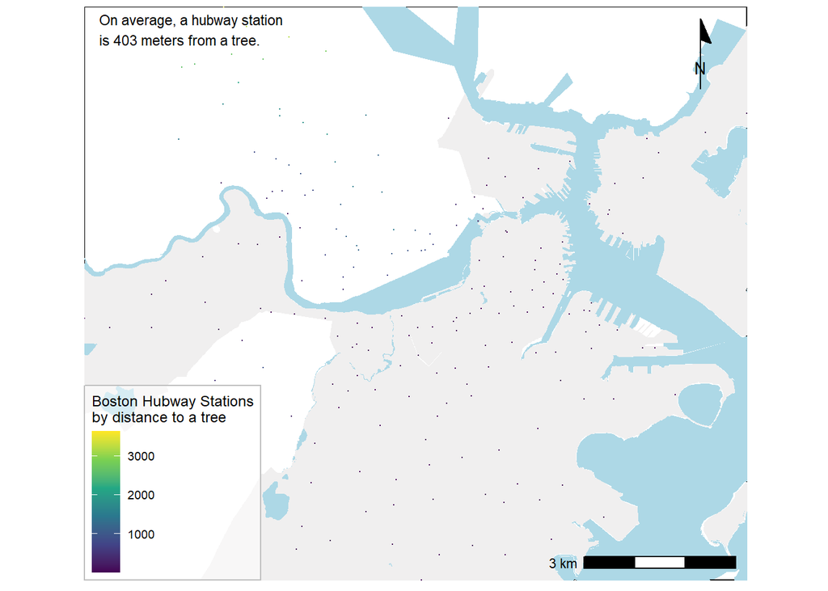

```r
right_side <- st_bbox(hubwaystations)$xmax
left_side  <- st_bbox(hubwaystations)$xmin
top_side <- st_bbox(hubwaystations)$ymax
bottom_side <- st_bbox(hubwaystations)$ymin
ggplot(water) +
  geom_sf(data= climate_vulnerability, fill = "#f0efef", color = NA) +
  geom_sf(fill = "lightblue", color = NA) +
  geom_sf(data = hubwaystations, size = 0.1,
          aes(color = tree_dist)) +
  coord_sf(xlim = c(left_side, right_side),
           ylim = c(bottom_side, top_side), expand = FALSE) +
  scale_color_viridis_c(name =
                          "Boston Hubway Stations\nby distance to a tree") +
  annotation_scale(location = "br") +
  annotation_north_arrow(location = "tr",
                         style = north_arrow_minimal()) +
  annotate(geom = "text", x = left_side + 300,
           y = top_side - 750,
           label = paste("On average, a hubway station\nis ",
                         prettyNum(avg_tree_dist, digits = 3),
                         " meters from a tree.",
                         sep = ""),
           hjust = 0, vjust = 0, size = 3) +
  theme_map() +
  theme(panel.background = element_rect(fill = "white"),
        legend.background = element_rect(fill = alpha("white", 0.5),
                                         color = "gray"))
```

## Identifying overlapping polygons

I want to map how public space is distributed in tracts most vulnerable by the climate crisis.

```r
max_climate_vulnerability <- max_climate_vulnerability %>%
  mutate(num_openspace = lengths(st_overlaps(max_climate_vulnerability, open_space))) %>%
  mutate(has_openspace = num_openspace > 0)
```

How many tracts vulnerable to the climate crisis have access to open spaces?

```r
n_os_cvuln <- sum(max_climate_vulnerability$has_openspace)
n_os_cvuln
```

```
## [1] 48
```

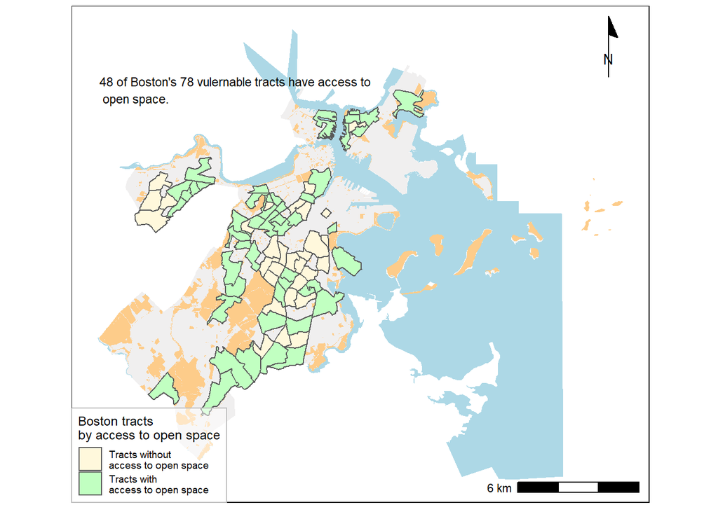

```r
left_side  <- st_bbox(open_space)$xmin
top_side <- st_bbox(open_space)$ymax
ggplot(open_space) +
  geom_sf(data = water, fill = "lightblue", color = NA) +
  geom_sf(data= climate_vulnerability, fill = "#f0efef", color = NA) +
  geom_sf(fill = "#fdcc8a", color = NA) +
  geom_sf(data = max_climate_vulnerability,
          aes(fill = has_openspace)) +
  scale_fill_manual(values = c("cornsilk1", "darkseagreen1"),
          name = "Boston tracts\nby access to open space",
          labels = c("Tracts without\naccess to open space",
                     "Tracts with \naccess to open space")) +
  annotation_scale(location = "br") +
  annotation_north_arrow(location = "tr",
                         style = north_arrow_minimal()) +
  annotate(geom = "text", x = left_side,
           y = top_side - 1000,
           label = paste(n_os_cvuln ,
                         "of Boston's",
                         length(max_climate_vulnerability$FID_1),
                         "vulernable tracts have access to \n",
                         "open space."),
           hjust = 0, vjust = 0, size = 3) +
  theme_map() +
  theme(panel.background = element_rect(fill = "white"),
        legend.background = element_rect(fill = alpha("white", 0.5),
                                         color = "gray"))
```

## Hubway stations in climate vulnerable tracts

Now, I’ll plot how many hubway stations there are in climate vulnerable tracts.

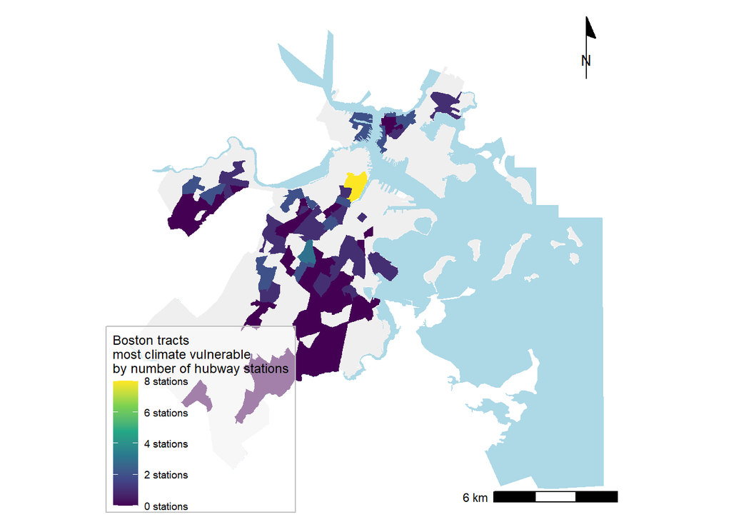

```r
max_climvuln_hub <- max_climate_vulnerability %>%
  mutate(num_hubscv = lengths(st_covers(max_climate_vulnerability, hubwaystations)))
ggplot(max_climvuln_hub) +
  geom_sf(data = water, fill = "lightblue", color = NA) +
  geom_sf(data= climate_vulnerability, fill = "#f0efef", color = NA) +
  geom_sf(color = NA,
          aes(fill = num_hubscv)) +
  scale_fill_viridis_c(name = "Boston tracts \nmost climate vulnerable \nby number of hubway stations",
                       breaks = breaks <- seq(0, 10, by = 2),
                       labels = paste(prettyNum(breaks, big.mark = ","),
                                      "stations")) +
  annotation_scale(location = "br") +
  annotation_north_arrow(location = "tr",
                         style = north_arrow_minimal()) +
theme_map() +
  theme(legend.background = element_rect(fill = alpha("white", 0.5),
                                         color = "gray"))
```

## Calculating areas and densities

Density of hubway stations in climate-vulnerable tracts.

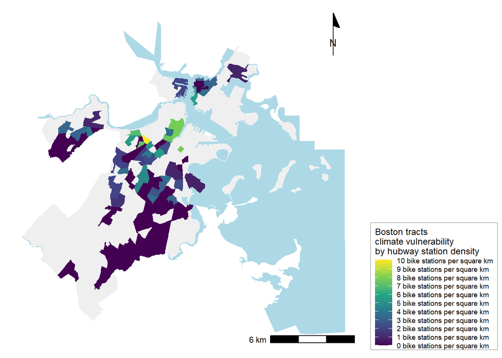

```r
max_climvuln_hub <- max_climvuln_hub %>%
  mutate(area = set_units(st_area(max_climvuln_hub), km^2)) %>%
  mutate(hub_dens = as.numeric(num_hubscv / area))
ggplot(max_climvuln_hub) +
  geom_sf(data = water, fill = "lightblue", color = NA) +
  geom_sf(data= climate_vulnerability, fill = "#f0efef", color = NA) +
  geom_sf(color = NA,
          aes(fill = hub_dens)) +
    scale_fill_viridis_c(name =
                           "Boston tracts\nclimate vulnerability\nby hubway station density",
                       breaks = breaks <- seq(0, 10, by = 1),
                       labels = paste(prettyNum(breaks, big.mark = ","),
                                      "bike stations per square km")) +
  annotation_scale(location = "br") +
  annotation_north_arrow(location = "tr",
                         style = north_arrow_minimal()) +
theme_map() +
  theme(legend.position = "right",
    legend.background = element_rect(fill = alpha("white", 0.5),
                                         color = "gray"))
```